# Exercise 6

문지원

2021 4 28

# 시각화 연습문제 [심화]

### 1. mpg 데이터의 cty(도시 연비)와 hwy(고속도로 연비) 간에 어떤 관계가 있는지 알아보려고 합니다. x축은 cty, y축은 hwy로 된 산점도를 만들어 보세요.

```r
library(dplyr)
```

```r
library(ggplot2)
mpg
```

```
## # A tibble: 234 x 11
##    manufacturer model    displ  year   cyl trans   drv     cty   hwy fl    class
##    <chr>        <chr>    <dbl> <int> <int> <chr>   <chr> <int> <int> <chr> <chr>
##  1 audi         a4         1.8  1999     4 auto(l~ f        18    29 p     comp~
##  2 audi         a4         1.8  1999     4 manual~ f        21    29 p     comp~
##  3 audi         a4         2    2008     4 manual~ f        20    31 p     comp~
##  4 audi         a4         2    2008     4 auto(a~ f        21    30 p     comp~
##  5 audi         a4         2.8  1999     6 auto(l~ f        16    26 p     comp~
##  6 audi         a4         2.8  1999     6 manual~ f        18    26 p     comp~
##  7 audi         a4         3.1  2008     6 auto(a~ f        18    27 p     comp~
##  8 audi         a4 quat~   1.8  1999     4 manual~ 4        18    26 p     comp~
##  9 audi         a4 quat~   1.8  1999     4 auto(l~ 4        16    25 p     comp~
## 10 audi         a4 quat~   2    2008     4 manual~ 4        20    28 p     comp~
## # ... with 224 more rows
```

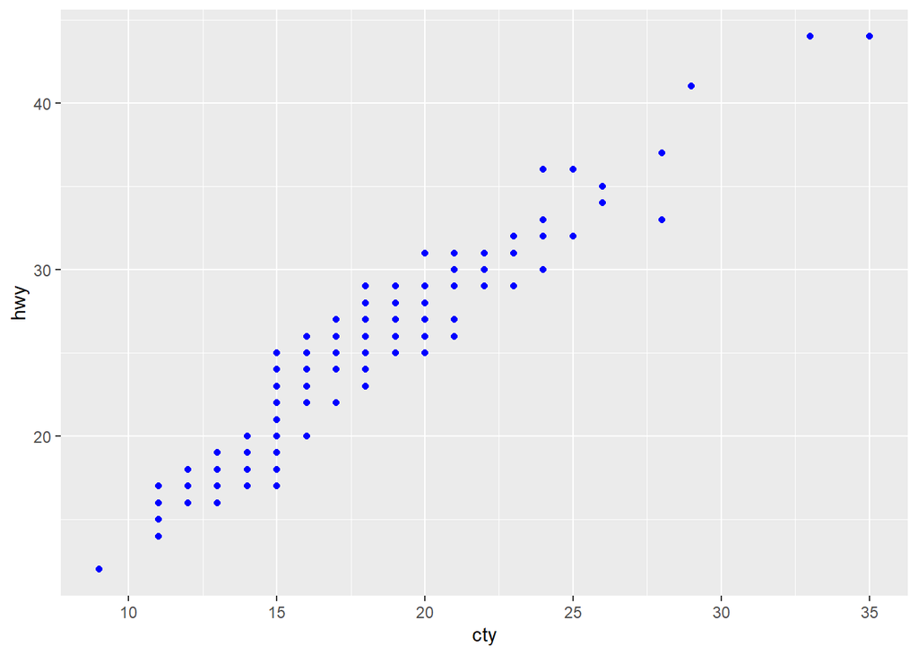

```r
ggplot(data= mpg, aes(x=cty, y=hwy))+
   geom_point(col="blue")
```

### 2. 미국 지역별 인구통계 정보를 담은 ggplot2 패키지의 midwest 데이터를 이용해서 전체 인구와 아시아인 인구 간에 어떤 관계가 있는지 알아보려고 합니다. x축은 poptotal(전체 인구), y축은 popasian(아시아인 인구)으로 된 산점도를 만들어 보세요. 전체 인구는 50만 명 이하, 아시아인 인구는 1만 명 이하인 지역만 산점도에 표시되게 설정하세요.

```r
midwest
```

```
## # A tibble: 437 x 28
##      PID county  state  area poptotal popdensity popwhite popblack popamerindian
##    <int> <chr>   <chr> <dbl>    <int>      <dbl>    <int>    <int>         <int>
##  1   561 ADAMS   IL    0.052    66090      1271.    63917     1702            98
##  2   562 ALEXAN~ IL    0.014    10626       759      7054     3496            19
##  3   563 BOND    IL    0.022    14991       681.    14477      429            35
##  4   564 BOONE   IL    0.017    30806      1812.    29344      127            46
##  5   565 BROWN   IL    0.018     5836       324.     5264      547            14
##  6   566 BUREAU  IL    0.05     35688       714.    35157       50            65
##  7   567 CALHOUN IL    0.017     5322       313.     5298        1             8
##  8   568 CARROLL IL    0.027    16805       622.    16519      111            30
##  9   569 CASS    IL    0.024    13437       560.    13384       16             8
## 10   570 CHAMPA~ IL    0.058   173025      2983.   146506    16559           331
## # ... with 427 more rows, and 19 more variables: popasian <int>,
## #   popother <int>, percwhite <dbl>, percblack <dbl>, percamerindan <dbl>,
## #   percasian <dbl>, percother <dbl>, popadults <int>, perchsd <dbl>,
## #   percollege <dbl>, percprof <dbl>, poppovertyknown <int>,
## #   percpovertyknown <dbl>, percbelowpoverty <dbl>, percchildbelowpovert <dbl>,
## #   percadultpoverty <dbl>, percelderlypoverty <dbl>, inmetro <int>,
## #   category <chr>
```

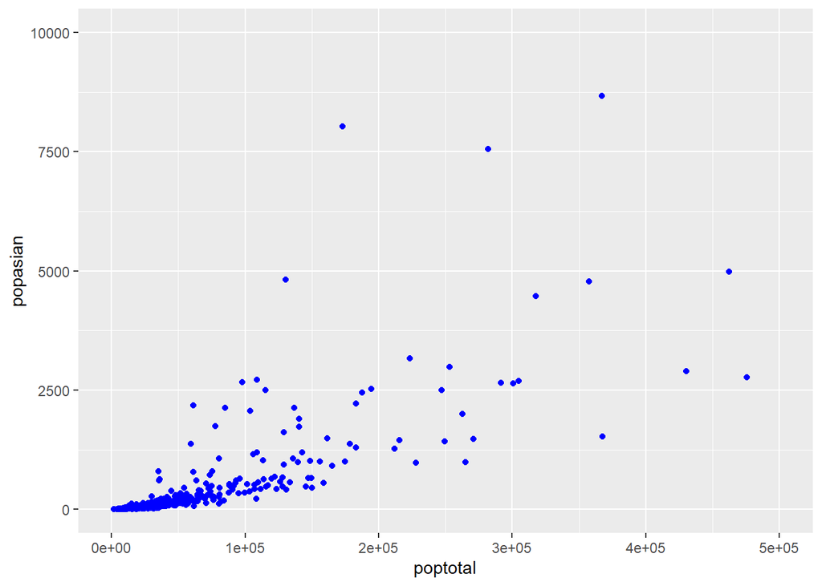

```r
ggplot(data= midwest, aes(x= poptotal, y= popasian)) +
   geom_point(col='blue') +
   xlim(0, 500000) +
   ylim(0, 10000)
```

### 3. 어떤 회사에서 생산한 “suv” 차종의 도시 연비가 높은지 알아보려고 합니다. “suv” 차종을 대상으로 평균 cty(도시 연비)가 가장 높은 회사 다섯 곳을 막대 그래프로 표현해 보세요. 막대는 연비가 높은 순으로 정렬하세요.

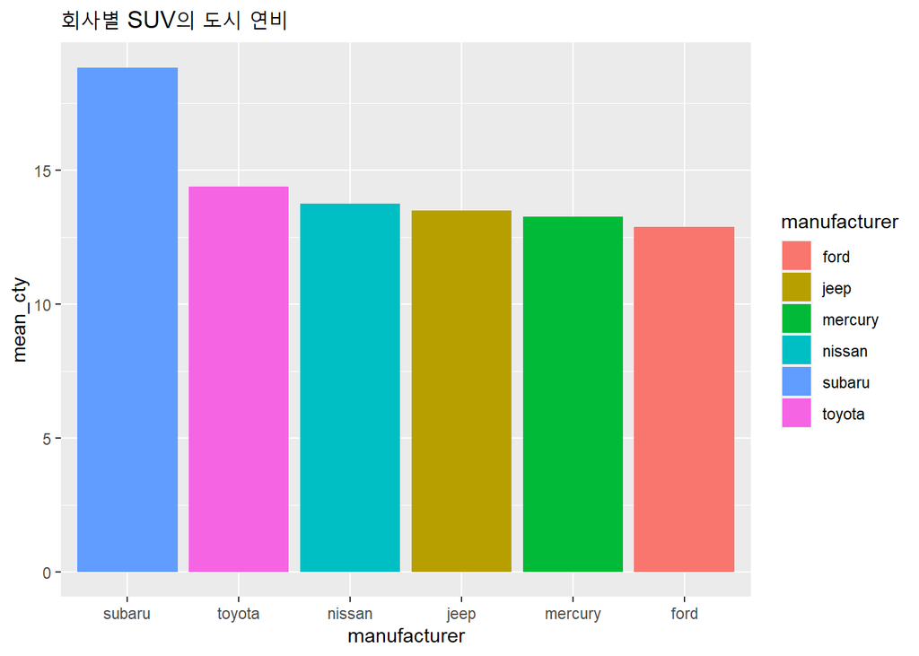

```r
suv_cty <- mpg %>%
   filter(class== 'suv') %>%
   group_by(manufacturer) %>%
   summarize(mean_cty=mean(cty)) %>%
   arrange(desc(mean_cty)) %>%
   head()
ggplot(data= suv_cty, aes(reorder(manufacturer, -mean_cty), y= mean_cty)) +
   geom_bar(stat='identity', aes(fill= manufacturer)) +
   labs(x= 'manufacturer',
        y= 'mean_cty',
        title= '회사별 SUV의 도시 연비'
        )
```

### 4. 자동차 중에서 어떤 class(자동차 종류)가 가장 많은지 알아보려고 합니다. 자동차 종류별 빈도를 표현한 막대 그래프를 만들어 보세요.

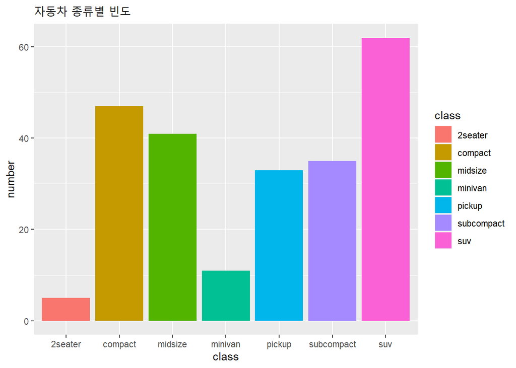

```r
ggplot(data= mpg, aes(x= class)) +
   geom_bar(aes(fill= class)) +
   labs(x= 'class',
       y= 'number',
       title= '자동차 종류별 빈도')
```

### 5. economics 데이터를 이용해서 psavert(개인 저축률)가 시간에 따라서 어떻게 변해왔는지 알아보려고 합니다. 시간에 따른 개인 저축률의 변화를 나타낸 시계열 그래프를 만들어 보세요.

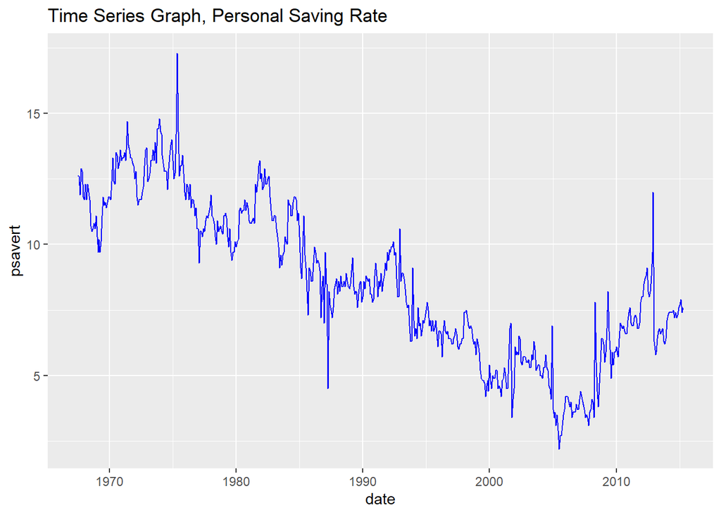

```r
ggplot(data= economics, aes(x= date, y= psavert)) +
   geom_line(color="blue") +
   ggtitle('Time Series Graph, Personal Saving Rate')
```

### 6. class(자동차 종류)가 “compact”, “subcompact”, “suv”인 자동차의 cty(도시 연비)가 어떻게 다른지 비교해보려고 합니다. 세 차종의 cty를 나타낸 상자 그림을 만들어보세요.

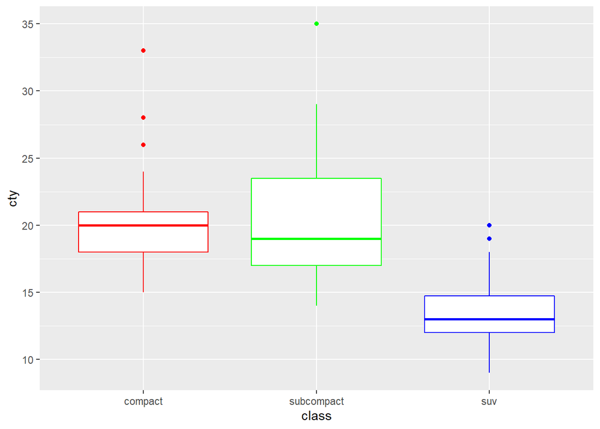

```r
mpg_c <- mpg %>%
   filter(class %in% c('compact', 'subcompact', 'suv'))
ggplot(data= mpg_c, aes(x= class, y= cty)) +
   geom_boxplot(color=c('red', 'green', 'blue'))
```

### 7. Diamonds 데이터 셋을 이용하여 다음 문제를 해결하세요. 단, 컬러, 제목, x축, y축 등 그래프를 예쁘게 작성하세요.

1. cut의 돗수를 보여주는 그래프를 작성하세요.

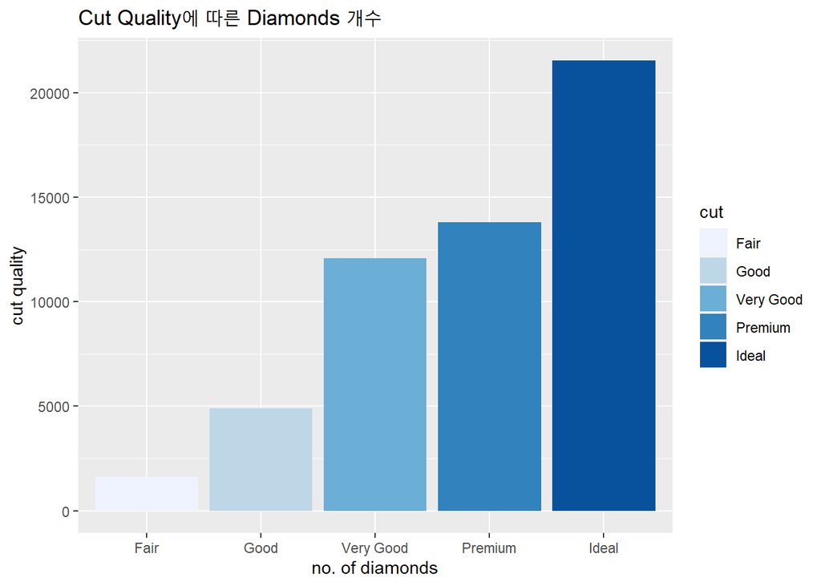

```r
ggplot(data= diamonds, aes(x= cut)) +
   geom_bar(aes(fill= cut))+
   scale_fill_brewer(palette = "Blues") +
   labs(x= 'no. of diamonds',
        y= 'cut quality',
        title = "Cut Quality에 따른 Diamonds 개수")
```

2. cut에 따른 가격의 변화를 보여주는 그래프를 작성하세요.

```r
m_price<- diamonds %>%
   group_by(cut) %>%
   summarize(mean_price=mean(price))
m_price
```

```
## # A tibble: 5 x 2
##   cut       mean_price
##   <ord>          <dbl>
## 1 Fair           4359.
## 2 Good           3929.
## 3 Very Good      3982.
## 4 Premium        4584.
## 5 Ideal          3458.
```

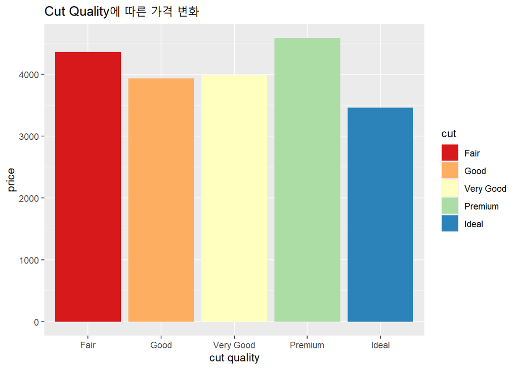

```r
ggplot(data= m_price, aes(x= cut, y= mean_price)) +
   geom_bar(stat = 'identity', aes(fill=cut)) +
   scale_fill_brewer(palette = "Spectral") +
   labs(x= 'cut quality',
        y= 'price',
        title= "Cut Quality에 따른 가격 변화")
```

3. cut과 color에 따른 가격의 변화를 보여주는 그래프를 작성하세요.

```r
m.price<- diamonds %>%
   group_by(cut, color) %>%
   summarize(mean.price=mean(price))
m.price
```

```
## # A tibble: 35 x 3
## # Groups:   cut [5]
##    cut   color mean.price
##    <ord> <ord>      <dbl>
##  1 Fair  D          4291.
##  2 Fair  E          3682.
##  3 Fair  F          3827.
##  4 Fair  G          4239.
##  5 Fair  H          5136.
##  6 Fair  I          4685.
##  7 Fair  J          4976.
##  8 Good  D          3405.
##  9 Good  E          3424.
## 10 Good  F          3496.
## # ... with 25 more rows
```

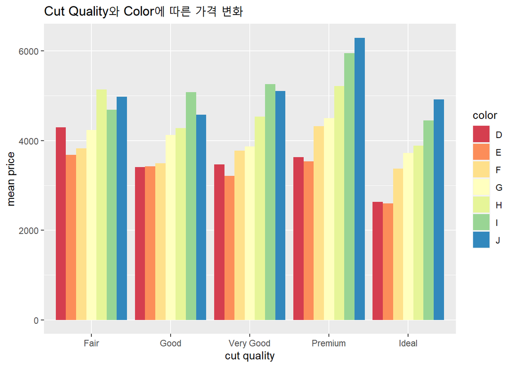

```r
ggplot(data= m.price, aes(x= cut, y= mean.price)) +
   geom_bar(stat = 'identity', aes(fill=color), position= 'dodge') +
   scale_fill_brewer(palette = "Spectral") +
   labs(x= 'cut quality',
        y= 'mean price',
        title= "Cut Quality와 Color에 따른 가격 변화")
```